# Portfolio: Part 2

John Higdon

12/3/2019

To begin, let’s bring in the work completed from the first deliverable.

```r
library("knitr")
purl("p1.Rmd", output = "p1.r")
```

```
## [1] "p1.R"
```

```r
source("p1.r")
```

[output not shown]

We are going to continue using the two data sets retrieved from the previous deliverable. In part 1 we introduced a secondary data set already which provides additional information about personal income based on state or region, and will continue to use it in order to allow the fruits of our labor to be utilized. We tidied said data to explore quarterly values from q1 2017 until q1 2019. In doing so, we hope to gain insight about whether or not GDP or Per Capita Personal Income has any influence on one another, as well as the state/region they reside in.

As we discovered previously, our datasets could use a bit more cleanup. Both the gdpByState2017 and personalIncome2017 contain data for both states and regional areas in the United States. Let’s split up these tables further!

Our goal is to retrieve tables for gdp by state, gdp by region, personal income by state and personal income by region. Doing so may elimate outliers discovered in our previous attempt, and will certainly provide us with more tidy data to parse through.

The predictions we’d eventually like to attempt based on our tidy datasets are the following:

1. Can state/region be used to predict average GDP? How about average personal income?
2. Can average GDP be used to predict average personal income based on state or region?
3. Conversely, can average personal income predict average GDP based on state or region?

```r
# Split gdp dataset into Regions and States
gdpByRegion2017 <- gdpByState2017[-c(1:1224),]  # removes the first 1225 rows, leaving us with regional data
gdpByState2017 <- gdpByState2017[-c(1225:1416),] # removes rows containing regional data

# Split personal income dataset into Regions and States
statePersonalIncome2017 <- personalIncome2017[-c(154:184),]  # removes rows containing regional data
regionalPersonalIncome2017 <- personalIncome2017[-c(1:153),]  # removes the first 153 rows, leaving us with regional data.
regionalPersonalIncome2017 <- regionalPersonalIncome2017[-c(25:31),]  # cleans up legend at bottom of dataset which is not needed for analysis
```

Let’s remove a bit more data from our personal data tables. In regards to this project, we only care about Per Capita personal income (which is the state or regions total personal income in millions of dollars divided by the total population of the state or region).

```r
# remove the total population and personal income. We will be focussing on Per Capita personal income
# for this project
statePersonalIncome2017 <- statePersonalIncome2017 %>% filter(!(LineCode=="2")) %>% filter(!(LineCode=="1"))
regionalPersonalIncome2017 <- regionalPersonalIncome2017 %>% filter(!(LineCode=="2")) %>% filter(!(LineCode=="1"))
```

We can further clean up our datasets by removing the GeoFips column. We will keep LineCode so we can use said column to parse for information we may want to glean at another time.

```r
# Remove first column, which is the GeoFips portion we do not need
gdpByState2017 <- gdpByState2017[, -c(1)]
gdpByRegion2017 <- gdpByRegion2017[, -c(1)]
regionalPersonalIncome2017 <- regionalPersonalIncome2017[, -c(1)]
statePersonalIncome2017 <- statePersonalIncome2017[, -c(1)]
```

The four tables we have available for gdp by state, gdp by region, state personal income and regional personal income are now in a tidy state.

We are ready to begin contemplating what kind of models we could create in order to gain insights about our data.

In order to begin exploring the possibilities, let’s create new dataframes that determine the average gdp or personal income for each observation.

```r
# Table 1: Average GDP by State
temp_gdpByState <- tidyr::gather(gdpByState2017, quarter, avg_gdp, 4:12)
avg_gdpByState <- aggregate(avg_gdp ~ GeoName, temp_gdpByState, mean)
avg_gdpByState
```

```
##                 GeoName    avg_gdp
## 1               Alabama  27242.725
## 2                Alaska   6249.929
## 3               Arizona  41853.691
## 4              Arkansas  15936.127
## 5            California 362504.553
## 6              Colorado  44289.589
## 7           Connecticut  34002.127
## 8              Delaware   9944.628
## 9  District of Columbia  18425.376
## 10              Florida 124496.765
## 11              Georgia  72153.379
## 12               Hawaii  10697.563
## 13                Idaho   9363.754
## 14             Illinois 107219.009
```

[output cut: 37 more lines]

```r
# Table 2: Average GDP by Region
temp_gdpByRegion <- tidyr::gather(gdpByRegion2017, quarter, avg_gdp, 4:12)
avg_gdpByRegion <- aggregate(avg_gdp ~ GeoName, temp_gdpByRegion, mean)
avg_gdpByRegion
```

```
##          GeoName   avg_gdp
## 1       Far West 496815.99
## 2    Great Lakes 349086.49
## 3        Mideast 562800.35
## 4    New England 150485.95
## 5         Plains 157871.79
## 6 Rocky Mountain  96661.97
## 7      Southeast 529081.34
## 8      Southwest 294693.25
```

```r
# Table 3: Average Personal Income by State
temp_statePersonalIncome <- tidyr::gather(statePersonalIncome2017, quarter, avg_income, 4:12)
avg_personalIncomeByState <- aggregate(avg_income ~ GeoName, temp_statePersonalIncome, mean)
avg_personalIncomeByState
```

```
##                 GeoName avg_income
## 1               Alabama   41570.67
## 2               Alaska*   58422.67
## 3               Arizona   43639.89
## 4              Arkansas   42564.00
## 5            California   62259.44
## 6              Colorado   57272.11
## 7           Connecticut   74802.78
## 8              Delaware   51598.89
## 9  District of Columbia   80821.22
## 10              Florida   49215.78
## 11              Georgia   45740.56
## 12              Hawaii*   54550.78
## 13                Idaho   43198.56
## 14             Illinois   55704.33
```

[output cut: 37 more lines]

```r
# Table 4: Average Personal Income by Region
temp_regionalPersonalIncome <- tidyr::gather(regionalPersonalIncome2017, quarter, avg_income, 4:12)
avg_personalIncomeByRegion <- aggregate(avg_income ~ GeoName, temp_regionalPersonalIncome, mean)
avg_personalIncomeByRegion
```

```
##          GeoName avg_income
## 1       Far West   60140.89
## 2    Great Lakes   50096.44
## 3        Mideast   63373.78
## 4    New England   66623.89
## 5         Plains   51163.78
## 6 Rocky Mountain   51358.44
## 7      Southeast   46565.67
## 8      Southwest   47605.11
```

```r
# Table 5: Average GDP by State Industry
avg_gdpByStateIndustry <- aggregate(avg_gdp ~ Description, temp_gdpByState, mean)
avg_gdpByStateIndustry
```

```
##                                                                 Description
## 1                                           Accommodation and food services
## 2  Administrative and support and waste management and remediation services
## 3                                Agriculture, forestry, fishing and hunting
## 4                                                        All industry total
## 5                                       Arts, entertainment, and recreation
## 6                                                              Construction
## 7                                               Durable goods manufacturing
## 8                                                      Educational services
## 9                                                     Finance and insurance
## 10                                    Government and government enterprises
## 11                                        Health care and social assistance
## 12                                                              Information
## 13                                  Management of companies and enterprises
## 14                                                            Manufacturing
```

[output cut: 35 more lines]

```r
# Table 6: Average GDP by Regional Industry
avg_gdpByRegionIndustry <- aggregate(avg_gdp ~ Description, temp_gdpByRegion, mean)
avg_gdpByRegionIndustry
```

```
##                                                                 Description
## 1                                           Accommodation and food services
## 2  Administrative and support and waste management and remediation services
## 3                                Agriculture, forestry, fishing and hunting
## 4                                                        All industry total
## 5                                       Arts, entertainment, and recreation
## 6                                                              Construction
## 7                                               Durable goods manufacturing
## 8                                                      Educational services
## 9                                                     Finance and insurance
## 10                                    Government and government enterprises
## 11                                        Health care and social assistance
## 12                                                              Information
## 13                                  Management of companies and enterprises
## 14                                                            Manufacturing
```

[output cut: 35 more lines]

```r
# Remove temporary tables no longer needed for analysis
rm(temp_gdpByState)
rm(temp_gdpByRegion)
rm(temp_statePersonalIncome)
rm(temp_regionalPersonalIncome)
```

Let’s merge the gdp by state and personal income by state tables together. First we need to clean up entries for Alaska and Hawaii in the personal income dataset as they contained an * appended to the end of their respective names.

```r
# remove all whitespace
avg_personalIncomeByState$GeoName <- avg_personalIncomeByState$GeoName %>%
                                     trimws()

# and rename our observations mentioned above
avg_personalIncomeByState$GeoName[2] <- "Alaska"
avg_personalIncomeByState$GeoName[12] <- "Hawaii"
```

Now let’s merge our datasets together! Doing so will allow us to test if there’s a correlation between average GDP and personal income by state and region.

```r
# Table 7: Average GDP and Personal Income by State
avg_gdpAndPersonalIncomeByState <- merge(avg_gdpByState, avg_personalIncomeByState)
avg_gdpAndPersonalIncomeByState
```

```
##                 GeoName    avg_gdp avg_income
## 1               Alabama  27242.725   41570.67
## 2                Alaska   6249.929   58422.67
## 3               Arizona  41853.691   43639.89
## 4              Arkansas  15936.127   42564.00
## 5            California 362504.553   62259.44
## 6              Colorado  44289.589   57272.11
## 7           Connecticut  34002.127   74802.78
## 8              Delaware   9944.628   51598.89
## 9  District of Columbia  18425.376   80821.22
## 10              Florida 124496.765   49215.78
## 11              Georgia  72153.379   45740.56
## 12               Hawaii  10697.563   54550.78
## 13                Idaho   9363.754   43198.56
## 14             Illinois 107219.009   55704.33
```

[output cut: 37 more lines]

```r
# Table 8: Average GDP and Personal Income by Region
avg_gdpAndPersonalIncomeByRegion <- merge(avg_gdpByRegion, avg_personalIncomeByRegion)
avg_gdpAndPersonalIncomeByRegion
```

```
##          GeoName   avg_gdp avg_income
## 1       Far West 496815.99   60140.89
## 2    Great Lakes 349086.49   50096.44
## 3        Mideast 562800.35   63373.78
## 4    New England 150485.95   66623.89
## 5         Plains 157871.79   51163.78
## 6 Rocky Mountain  96661.97   51358.44
## 7      Southeast 529081.34   46565.67
## 8      Southwest 294693.25   47605.11
```

Using Table 7 and 8 above, let’s create simple models to glean information regarding the predictive qualities of our variables.

```r
# state models
model_gdpByState <- lm(avg_gdp ~ GeoName, data = avg_gdpAndPersonalIncomeByState)
model_incomeByState <- lm(avg_income ~ GeoName, data = avg_gdpAndPersonalIncomeByState)
model_gdpByIncomeState <- lm(avg_gdp ~ avg_income, data = avg_gdpAndPersonalIncomeByState)
model_incomeByGdpState <- lm(avg_income ~ avg_gdp, data = avg_gdpAndPersonalIncomeByState)

# regional models
model_gdpByRegion <- lm(avg_gdp ~ GeoName, data = avg_gdpAndPersonalIncomeByRegion)
model_incomeByRegion <- lm(avg_income ~ GeoName, data = avg_gdpAndPersonalIncomeByRegion)
model_gdpByIncomeRegion <- lm(avg_gdp ~ avg_income, data = avg_gdpAndPersonalIncomeByRegion)
model_incomeByGdpRegion <- lm(avg_income ~ avg_gdp, data = avg_gdpAndPersonalIncomeByRegion)
```

We’re now ready. Let’s summarize each of our models using the power of R and take a close look at the p-value presented. We will go through each model one at a time and explain the results.

State Models:

```r
summary(model_gdpByState)
```

```
##
## Call:
## lm(formula = avg_gdp ~ GeoName, data = avg_gdpAndPersonalIncomeByState)
##
## Residuals:
## ALL 51 residuals are 0: no residual degrees of freedom!
##
## Coefficients:
##                             Estimate Std. Error t value Pr(>|t|)
## (Intercept)                    27243         NA      NA       NA
## GeoNameAlaska                 -20993         NA      NA       NA
## GeoNameArizona                 14611         NA      NA       NA
## GeoNameArkansas               -11307         NA      NA       NA
## GeoNameCalifornia             335262         NA      NA       NA
## GeoNameColorado                17047         NA      NA       NA
## GeoNameConnecticut              6759         NA      NA       NA
## GeoNameDelaware               -17298         NA      NA       NA
## GeoNameDistrict of Columbia    -8817         NA      NA       NA
## GeoNameFlorida                 97254         NA      NA       NA
## GeoNameGeorgia                 44911         NA      NA       NA
## GeoNameHawaii                 -16545         NA      NA       NA
## GeoNameIdaho                  -17879         NA      NA       NA
## GeoNameIllinois                79976         NA      NA       NA
## GeoNameIndiana                 20615         NA      NA       NA
## GeoNameIowa                    -3271         NA      NA       NA
## GeoNameKansas                  -6479         NA      NA       NA
## GeoNameKentucky                -1134         NA      NA       NA
## GeoNameLouisiana                4342         NA      NA       NA
## GeoNameMaine                  -19429         NA      NA       NA
## GeoNameMaryland                21294         NA      NA       NA
## GeoNameMassachusetts           42317         NA      NA       NA
## GeoNameMichigan                39621         NA      NA       NA
## GeoNameMinnesota               18695         NA      NA       NA
## GeoNameMississippi            -13240         NA      NA       NA
## GeoNameMissouri                11940         NA      NA       NA
## GeoNameMontana                -21392         NA      NA       NA
## GeoNameNebraska               -12148         NA      NA       NA
## GeoNameNevada                  -7366         NA      NA       NA
## GeoNameNew Hampshire          -16781         NA      NA       NA
## GeoNameNew Jersey              49155         NA      NA       NA
```

[output cut: 9 more lines]

```
## GeoNameSouth Carolina           1293         NA      NA       NA
## GeoNameSouth Dakota           -20908         NA      NA       NA
## GeoNameTennessee               18264         NA      NA       NA
## GeoNameTexas                  190370         NA      NA       NA
## GeoNameUtah                    -5748         NA      NA       NA
## GeoNameVermont                -23146         NA      NA       NA
## GeoNameVirginia                36375         NA      NA       NA
## GeoNameWashington              40839         NA      NA       NA
## GeoNameWest Virginia          -17946         NA      NA       NA
## GeoNameWisconsin               15247         NA      NA       NA
## GeoNameWyoming                -21895         NA      NA       NA
##
## Residual standard error: NaN on 0 degrees of freedom
## Multiple R-squared:      1,  Adjusted R-squared:    NaN
## F-statistic:   NaN on 50 and 0 DF,  p-value: NA
```

The p-value calculated here was “NA”. Surely this is not a great predictor to further analyze.

```r
summary(model_incomeByState)
```

```
##
## Call:
## lm(formula = avg_income ~ GeoName, data = avg_gdpAndPersonalIncomeByState)
##
## Residuals:
## ALL 51 residuals are 0: no residual degrees of freedom!
##
## Coefficients:
##                             Estimate Std. Error t value Pr(>|t|)
## (Intercept)                  41570.7         NA      NA       NA
## GeoNameAlaska                16852.0         NA      NA       NA
## GeoNameArizona                2069.2         NA      NA       NA
## GeoNameArkansas                993.3         NA      NA       NA
## GeoNameCalifornia            20688.8         NA      NA       NA
## GeoNameColorado              15701.4         NA      NA       NA
## GeoNameConnecticut           33232.1         NA      NA       NA
## GeoNameDelaware              10028.2         NA      NA       NA
## GeoNameDistrict of Columbia  39250.6         NA      NA       NA
## GeoNameFlorida                7645.1         NA      NA       NA
## GeoNameGeorgia                4169.9         NA      NA       NA
## GeoNameHawaii                12980.1         NA      NA       NA
## GeoNameIdaho                  1627.9         NA      NA       NA
## GeoNameIllinois              14133.7         NA      NA       NA
## GeoNameIndiana                4834.7         NA      NA       NA
## GeoNameIowa                   7551.9         NA      NA       NA
## GeoNameKansas                 8870.1         NA      NA       NA
## GeoNameKentucky                339.2         NA      NA       NA
## GeoNameLouisiana              3801.7         NA      NA       NA
## GeoNameMaine                  6449.9         NA      NA       NA
## GeoNameMaryland              20675.7         NA      NA       NA
## GeoNameMassachusetts         28829.8         NA      NA       NA
## GeoNameMichigan               5998.2         NA      NA       NA
## GeoNameMinnesota             14924.0         NA      NA       NA
## GeoNameMississippi           -4276.0         NA      NA       NA
## GeoNameMissouri               5413.2         NA      NA       NA
## GeoNameMontana                5071.1         NA      NA       NA
## GeoNameNebraska              10597.4         NA      NA       NA
## GeoNameNevada                 6690.7         NA      NA       NA
## GeoNameNew Hampshire         18673.6         NA      NA       NA
## GeoNameNew Jersey            25376.2         NA      NA       NA
```

[output cut: 9 more lines]

```
## GeoNameSouth Carolina         1540.4         NA      NA       NA
## GeoNameSouth Dakota           9523.3         NA      NA       NA
## GeoNameTennessee              4599.4         NA      NA       NA
## GeoNameTexas                  7847.3         NA      NA       NA
## GeoNameUtah                   3858.1         NA      NA       NA
## GeoNameVermont               11820.1         NA      NA       NA
## GeoNameVirginia              15268.3         NA      NA       NA
## GeoNameWashington            19117.4         NA      NA       NA
## GeoNameWest Virginia         -1577.9         NA      NA       NA
## GeoNameWisconsin              9131.1         NA      NA       NA
## GeoNameWyoming               17248.7         NA      NA       NA
##
## Residual standard error: NaN on 0 degrees of freedom
## Multiple R-squared:      1,  Adjusted R-squared:    NaN
## F-statistic:   NaN on 50 and 0 DF,  p-value: NA
```

See above, similar outcome.

```r
summary(model_gdpByIncomeState)
```

```
##
## Call:
## lm(formula = avg_gdp ~ avg_income, data = avg_gdpAndPersonalIncomeByState)
##
## Residuals:
##    Min     1Q Median     3Q    Max
## -81613 -33874 -13166   6461 295351
##
## Coefficients:
##               Estimate Std. Error t value Pr(>|t|)
## (Intercept) -43145.742  50643.933  -0.852   0.3984
## avg_income       1.772      0.959   1.847   0.0707 .
## ---
## Signif. codes:  0 '***' 0.001 '**' 0.01 '*' 0.05 '.' 0.1 ' ' 1
##
## Residual standard error: 61780 on 49 degrees of freedom
## Multiple R-squared:  0.06511,    Adjusted R-squared:  0.04603
## F-statistic: 3.413 on 1 and 49 DF,  p-value: 0.07074
```

Here we have a more interesting result. A p value of 0.07! It looks that we have an almost statistically significant correlation between gdp and income by state! It may proove worthwhile to further analyze this relationship in the results phase.

```r
summary(model_incomeByGdpState)
```

```
##
## Call:
## lm(formula = avg_income ~ avg_gdp, data = avg_gdpAndPersonalIncomeByState)
##
## Residuals:
##    Min     1Q Median     3Q    Max
## -13450  -5943  -1415   4099  29914
##
## Coefficients:
##              Estimate Std. Error t value Pr(>|t|)
## (Intercept) 5.023e+04  1.583e+03  31.740   <2e-16 ***
## avg_gdp     3.675e-02  1.989e-02   1.847   0.0707 .
## ---
## Signif. codes:  0 '***' 0.001 '**' 0.01 '*' 0.05 '.' 0.1 ' ' 1
##
## Residual standard error: 8899 on 49 degrees of freedom
## Multiple R-squared:  0.06511,    Adjusted R-squared:  0.04603
## F-statistic: 3.413 on 1 and 49 DF,  p-value: 0.07074
```

Similar to the above. This is expected because it is the inverse of the previous model.

Regional Models:

```r
summary(model_gdpByRegion)
```

```
##
## Call:
## lm(formula = avg_gdp ~ GeoName, data = avg_gdpAndPersonalIncomeByRegion)
##
## Residuals:
## ALL 8 residuals are 0: no residual degrees of freedom!
##
## Coefficients:
##                       Estimate Std. Error t value Pr(>|t|)
## (Intercept)             496816         NA      NA       NA
## GeoNameGreat Lakes     -147730         NA      NA       NA
## GeoNameMideast           65984         NA      NA       NA
## GeoNameNew England     -346330         NA      NA       NA
## GeoNamePlains          -338944         NA      NA       NA
## GeoNameRocky Mountain  -400154         NA      NA       NA
## GeoNameSoutheast         32265         NA      NA       NA
## GeoNameSouthwest       -202123         NA      NA       NA
##
## Residual standard error: NaN on 0 degrees of freedom
## Multiple R-squared:      1,  Adjusted R-squared:    NaN
## F-statistic:   NaN on 7 and 0 DF,  p-value: NA
```

NAs calculated, not great to model.

```r
summary(model_incomeByRegion)
```

```
##
## Call:
## lm(formula = avg_income ~ GeoName, data = avg_gdpAndPersonalIncomeByRegion)
##
## Residuals:
## ALL 8 residuals are 0: no residual degrees of freedom!
##
## Coefficients:
##                       Estimate Std. Error t value Pr(>|t|)
## (Intercept)              60141         NA      NA       NA
## GeoNameGreat Lakes      -10044         NA      NA       NA
## GeoNameMideast            3233         NA      NA       NA
## GeoNameNew England        6483         NA      NA       NA
## GeoNamePlains            -8977         NA      NA       NA
## GeoNameRocky Mountain    -8782         NA      NA       NA
## GeoNameSoutheast        -13575         NA      NA       NA
## GeoNameSouthwest        -12536         NA      NA       NA
##
## Residual standard error: NaN on 0 degrees of freedom
## Multiple R-squared:      1,  Adjusted R-squared:    NaN
## F-statistic:   NaN on 7 and 0 DF,  p-value: NA
```

See above.

```r
summary(model_gdpByIncomeRegion)
```

```
##
## Call:
## lm(formula = avg_gdp ~ avg_income, data = avg_gdpAndPersonalIncomeByRegion)
##
## Residuals:
##     Min      1Q  Median      3Q     Max
## -227299 -174387    2337  171449  217718
##
## Coefficients:
##              Estimate Std. Error t value Pr(>|t|)
## (Intercept) 2.337e+05  5.432e+05   0.430    0.682
## avg_income  1.758e+00  9.862e+00   0.178    0.864
##
## Residual standard error: 199300 on 6 degrees of freedom
## Multiple R-squared:  0.005267,   Adjusted R-squared:  -0.1605
## F-statistic: 0.03177 on 1 and 6 DF,  p-value: 0.8644
```

A 0.86 p value was calculated, shows a weak at best possibility that gdp is affacted by personal income by region.

```r
summary(model_incomeByGdpRegion)
```

```
##
## Call:
## lm(formula = avg_income ~ avg_gdp, data = avg_gdpAndPersonalIncomeByRegion)
##
## Residuals:
##    Min     1Q Median     3Q    Max
##  -8648  -5160  -2748   5783  12545
##
## Coefficients:
##              Estimate Std. Error t value Pr(>|t|)
## (Intercept) 5.363e+04  6.259e+03   8.568 0.000139 ***
## avg_gdp     2.996e-03  1.681e-02   0.178 0.864399
## ---
## Signif. codes:  0 '***' 0.001 '**' 0.01 '*' 0.05 '.' 0.1 ' ' 1
##
## Residual standard error: 8228 on 6 degrees of freedom
## Multiple R-squared:  0.005267,   Adjusted R-squared:  -0.1605
## F-statistic: 0.03177 on 1 and 6 DF,  p-value: 0.8644
```

See above.

Visualizations:

Pictured below are scatter plots of average gdp vs average income for both state and regional data. We can see by inspection that there is a slight, positive correlation between average gdp and income at a State level. Regional data has less data points, and thus shows a much looser correlation. We can see by checking the correlation coefficients of each that, indeed, average gdp and income at a state level has a positive correlation with a coefficient of 0.25. Regional data is less correlated with a coefficient of < 0.1.

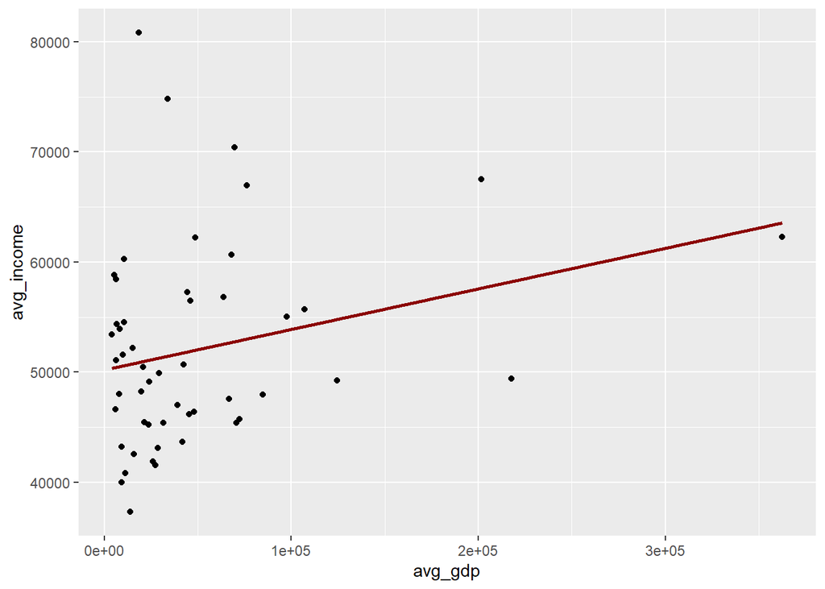

```r
# avg_gdp vs avg_income by State in Millions in dollars
ggplot(avg_gdpAndPersonalIncomeByState, aes(x = avg_gdp, y = avg_income)) + geom_point() + geom_smooth(method=lm, se=FALSE, color="darkred")
```

```r
# determine correlation coefficient
cor(avg_gdpAndPersonalIncomeByState$avg_gdp, avg_gdpAndPersonalIncomeByState$avg_income)
```

```
## [1] 0.2551682
```

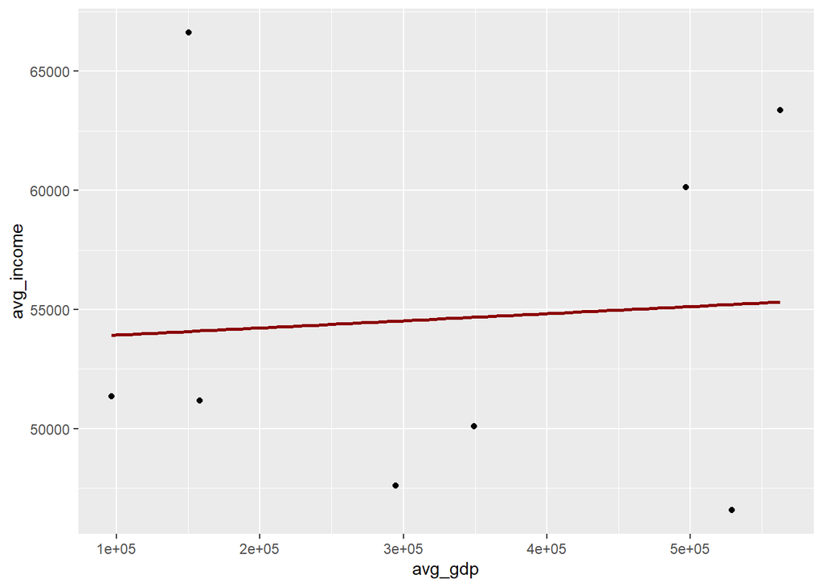

```r
# average gdp vs average income by Region in Millions of dollars
ggplot(avg_gdpAndPersonalIncomeByRegion, aes(x = avg_gdp, y = avg_income)) + geom_point() + geom_smooth(method=lm, se=FALSE, color="darkred")
```

```r
# determine correlation coefficient
cor(avg_gdpAndPersonalIncomeByRegion$avg_gdp, avg_gdpAndPersonalIncomeByRegion$avg_income)
```

```
## [1] 0.07257497
```

Discussion:

We see that we can potentially use a model that predicts average gdp by average income or vice versa due to the statistical significance of a correlation being present between the two has a p value that is nearly 0.05 (we found 0.07 in the above analysis). Predicting by state or region name didn’t prove to be a decent predictor of gdp or income in the above anaysis.

Possible limitations could be the size of the second data set used. Another is the statistical measure chosen, which is mean or average. Discrepencies in personal income especially can be drastically altered if wide ranges of values are accumulated in a region, area or state. If such skew is present, the median could prove a better metric to analyze.

We will continue our analysis and discussion the third part of the project, located here: [Portfolio: Part 3](https://violetinferno.github.io/DataSciencePortfolio/p3.html)